# Assignment 3

# Choose any eight variables and create a corrplot and correlation matrix

The eight variables I’m choosing are from the Kuperman Age of Acq Norms and the Glasgow Valence Norms. From Kup I’m using age of acq, number of letters, number of syllables, number of phonemes. From Glasgow I’m using concreteness, imageability, valence, and familiarity.

Make a new dataframe that includes only the variables I’m interested in. Call new dataset ‘MKOmegalex’ and check it out.

```r
MKOmegalex <- select(messymegalex, kup_aoa, kup_nlett, kup_nsyll, kup_nphon, gls_cnc,
    gls_img, gls_valence, gls_fam)
str(MKOmegalex)
```

```
## 'data.frame':    73459 obs. of  8 variables:
##  $ kup_aoa    : num  15.17 13.06 9.95 12.6 14.94 ...
##  $ kup_nlett  : int  8 5 10 8 10 7 9 6 8 9 ...
##  $ kup_nsyll  : int  3 2 4 3 4 3 4 2 3 3 ...
##  $ kup_nphon  : int  6 3 8 7 9 7 9 6 8 8 ...
##  $ gls_cnc    : num  5.46 5.91 3.29 3.37 3.29 ...
##  $ gls_img    : num  4.39 5.34 3.18 2.52 2.57 ...
##  $ gls_valence: num  2.86 5.78 5.25 3.77 3.88 ...
##  $ gls_fam    : num  2.38 3.32 5.12 3.97 3.1 ...
```

```r
glimpse(MKOmegalex)
```

```
## Observations: 73,459
## Variables: 8
## $ kup_aoa     <dbl> 15.17000, 13.06000, 9.95000, 12.60000, 14.94000, 8.61000,…
## $ kup_nlett   <int> 8, 5, 10, 8, 10, 7, 9, 6, 8, 9, 10, 5, 7, 4, 5, 8, 6, 6, …
## $ kup_nsyll   <int> 3, 2, 4, 3, 4, 3, 4, 2, 3, 3, 4, 2, 4, 2, 2, 3, 2, 2, 2, …
## $ kup_nphon   <int> 6, 3, 8, 7, 9, 7, 9, 6, 8, 8, 7, 4, 7, 4, 4, 7, 5, 6, 6, …
## $ gls_cnc     <dbl> 5.455, 5.906, 3.286, 3.367, 3.292, 6.606, 5.735, 4.441, 4…
## $ gls_img     <dbl> 4.391, 5.344, 3.177, 2.516, 2.571, 6.235, 5.030, 4.265, 4…
## $ gls_valence <dbl> 2.864, 5.781, 5.250, 3.767, 3.880, 5.486, 5.212, 2.177, 1…
## $ gls_fam     <dbl> 2.382, 3.324, 5.121, 3.971, 3.097, 4.636, 4.807, 4.364, 5…
```

Here’s the correlation matrix, it will use all eight variables.

```r
# make a conventional pearson correlation matrix first
megalex.corr <- cor(MKOmegalex, use = "complete.obs", method = "pearson")
my.col <- colorRampPalette(c("blue", "white", "pink"))
megalex.corr
```

```
##                kup_aoa   kup_nlett   kup_nsyll   kup_nphon     gls_cnc
## kup_aoa      1.0000000  0.35252018  0.38384857  0.38563886 -0.35638839
## kup_nlett    0.3525202  1.00000000  0.83090903  0.90976712 -0.18405257
## kup_nsyll    0.3838486  0.83090903  1.00000000  0.86268096 -0.20675562
## kup_nphon    0.3856389  0.90976712  0.86268096  1.00000000 -0.20904608
## gls_cnc     -0.3563884 -0.18405257 -0.20675562 -0.20904608  1.00000000
## gls_img     -0.4646622 -0.19146795 -0.21795732 -0.22164148  0.90840621
## gls_valence -0.1713555  0.04445483  0.04398532  0.04217338  0.05144614
## gls_fam     -0.6341814 -0.11412678 -0.13271510 -0.13250637  0.09194741
##                 gls_img gls_valence     gls_fam
## kup_aoa     -0.46466223 -0.17135554 -0.63418140
## kup_nlett   -0.19146795  0.04445483 -0.11412678
## kup_nsyll   -0.21795732  0.04398532 -0.13271510
## kup_nphon   -0.22164148  0.04217338 -0.13250637
## gls_cnc      0.90840621  0.05144614  0.09194741
## gls_img      1.00000000  0.08734883  0.21324764
## gls_valence  0.08734883  1.00000000  0.24793322
## gls_fam      0.21324764  0.24793322  1.00000000
```

Here’s the corrplot. These will use all eight variables which will be clustered by similarity. This uses the hclust and corrplot package, as well as vidris for the nice colors.

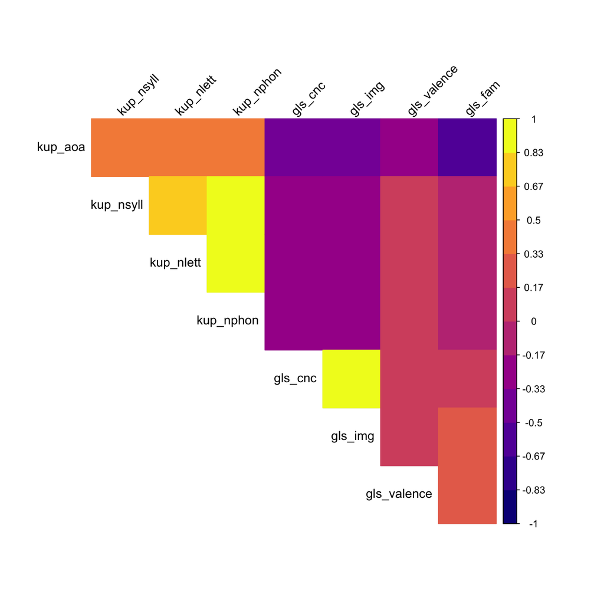

```r
# corrplot
corrplot(megalex.corr, method = "color", type = "upper", tl.srt = 45, tl.cex = 1,
    tl.col = "black", col = plasma(12), diag = F, order = "hclust", bg = "grey")
```